# 보험 사기 예측

윤지환

2016년 8월 12일

# 보험 사기 예측

```r
#Set path
setwd("C:\\Users\\jihwans.yun\\Desktop\\big")

# CSV Raw Data 불러오기
BGCON_CLAIM_DATA <- read.csv("data/BGCON_CLAIM_DATA.csv")
BGCON_CNTT_DATA <- read.csv("data/BGCON_CNTT_DATA.csv")
BGCON_CUST_DATA <- read.csv("data/BGCON_CUST_DATA.csv") # 기준 데이터
BGCON_FMLY_DATA <- read.csv("data/BGCON_FMLY_DATA.csv")
BGCON_FPINFO_DATA <- read.csv("data/BGCON_FPINFO_DATA.csv")

# 동일한 Level의 필드를 가진 데이터 Bind
BGCON_FMLY_DATA$SIU_CUST_YN <- NULL
BGCON_FPINFO_DATA$SIU_CUST_YN <- NULL
BGCON_CUST_FMLY_DATA <- merge(x = BGCON_CUST_DATA, y = BGCON_FMLY_DATA, by = 'CUST_ID', all = TRUE)
BGCON_CNTT_FPINFO_DATA <- merge(x = BGCON_CNTT_DATA, y = BGCON_FPINFO_DATA, by = 'CLLT_FP_PRNO', all = TRUE)


# SIU_CUST_YN 필드가 비어 있는 데이터(=Test Data)는 제거하고 시작
BGCON_CLAIM_DATA.df <- BGCON_CLAIM_DATA[!(BGCON_CLAIM_DATA$SIU_CUST_YN == ""),]
BGCON_CUST_FMLY_DATA.df <- BGCON_CUST_FMLY_DATA[!(BGCON_CUST_FMLY_DATA$SIU_CUST_YN == ""),]
BGCON_CNTT_FPINFO_DATA.df <- BGCON_CNTT_FPINFO_DATA[!(BGCON_CNTT_FPINFO_DATA$SIU_CUST_YN == ""),]

BGCON_CLAIM_DATA.df$SIU_CUST_YN <- factor(BGCON_CLAIM_DATA.df$SIU_CUST_YN)
BGCON_CLAIM_DATA.df$HOSP_SPEC_DVSN <- factor(BGCON_CLAIM_DATA.df$HOSP_SPEC_DVSN)
BGCON_CLAIM_DATA.df$ACCI_DVSN <- factor(BGCON_CLAIM_DATA.df$ACCI_DVSN)
BGCON_CLAIM_DATA.df$CRNT_PROG_DVSN <- factor(BGCON_CLAIM_DATA.df$CRNT_PROG_DVSN)

BGCON_CUST_FMLY_DATA.df$SIU_CUST_YN <- factor(BGCON_CUST_FMLY_DATA.df$SIU_CUST_YN)
BGCON_CUST_FMLY_DATA.df$RESI_TYPE_CODE <- factor(BGCON_CUST_FMLY_DATA.df$RESI_TYPE_CODE)
BGCON_CUST_FMLY_DATA.df$MINCRDT <- factor(BGCON_CUST_FMLY_DATA.df$MINCRDT)
BGCON_CUST_FMLY_DATA.df$MAXCRDT <- factor(BGCON_CUST_FMLY_DATA.df$MAXCRDT)

BGCON_CNTT_FPINFO_DATA.df$SIU_CUST_YN <- factor(BGCON_CNTT_FPINFO_DATA.df$SIU_CUST_YN)
BGCON_CNTT_FPINFO_DATA.df$CNTT_STAT_CODE <- factor(BGCON_CNTT_FPINFO_DATA.df$CNTT_STAT_CODE)
BGCON_CNTT_FPINFO_DATA.df$PAYM_CYCL_CODE <- factor(BGCON_CNTT_FPINFO_DATA.df$PAYM_CYCL_CODE)
BGCON_CNTT_FPINFO_DATA.df$SALE_CHNL_CODE <- factor(BGCON_CNTT_FPINFO_DATA.df$SALE_CHNL_CODE)
BGCON_CNTT_FPINFO_DATA.df$GOOD_CLSF_CDNM <- factor(BGCON_CNTT_FPINFO_DATA.df$GOOD_CLSF_CDNM)


# 데이터 셋 random reduced
suppressPackageStartupMessages({
  library(caret)
})
set.seed(1234)
BGCON_CLAIM_DATA.df.down <- downSample(x = BGCON_CLAIM_DATA.df, y = BGCON_CLAIM_DATA.df$SIU_CUST_YN)
set.seed(1234)
BGCON_CUST_FMLY_DATA.df.down <- downSample(x = BGCON_CUST_FMLY_DATA.df, y = BGCON_CUST_FMLY_DATA.df$SIU_CUST_YN)
set.seed(1234)
BGCON_CNTT_FPINFO_DATA.df.down <- downSample(x = BGCON_CNTT_FPINFO_DATA.df, y = BGCON_CNTT_FPINFO_DATA.df$SIU_CUST_YN)


# 불필요한 Raw Data 삭제
rm(BGCON_CUST_DATA)
rm(BGCON_FMLY_DATA)
rm(BGCON_CNTT_DATA)
rm(BGCON_FPINFO_DATA)
```

## EDA 수행

```r
#install.packages("Amelia")
suppressPackageStartupMessages({
  require(Amelia)
})
```

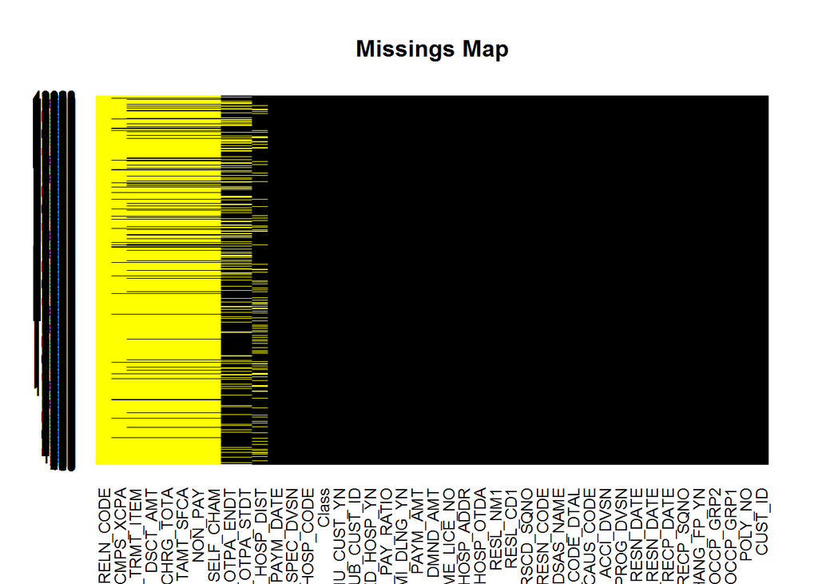

```r
missmap(BGCON_CLAIM_DATA.df.down, main="Missings Map", col=c("yellow", "black"), legend=FALSE)
```

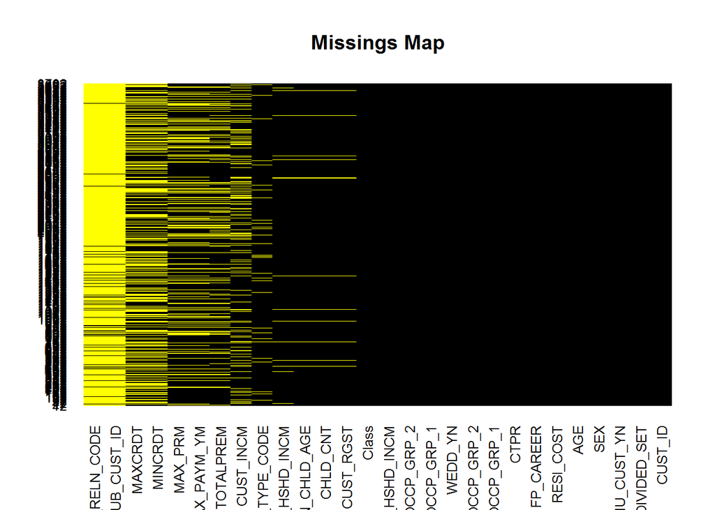

```r
#
missmap(BGCON_CUST_FMLY_DATA.df.down, main="Missings Map", col=c("yellow", "black"), legend=FALSE)
```

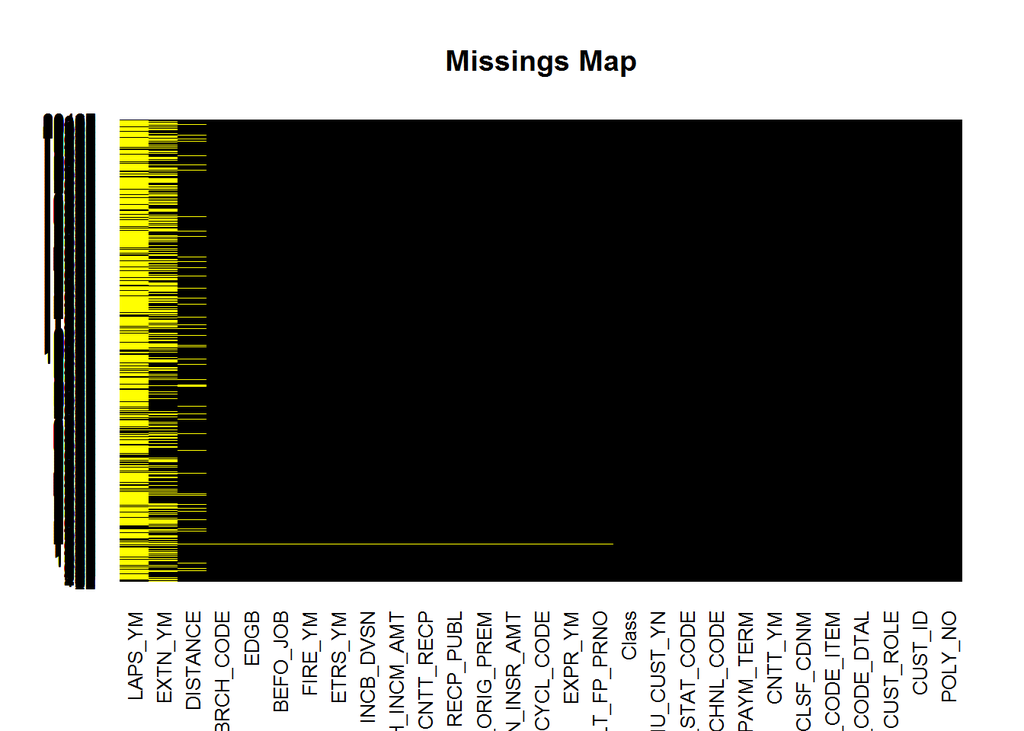

```r
#
missmap(BGCON_CNTT_FPINFO_DATA.df.down, main="Missings Map", col=c("yellow", "black"), legend=FALSE)
```

- 실효년월(LAPS_YM) 이 대부분 비어 있음
- 소멸년월(EXTN_YM) 많이 비어 있음
- FP와 고객간의거리(DISTANCE)는 일부 비어 있음
- MAXCRDT, MINCRDT는 중요한 factor로 보이지만 많은 데이터가 비어 있음

```r
#install.packages("Hmisc")
suppressPackageStartupMessages({
  library(Hmisc)
})
names(BGCON_CLAIM_DATA.df.down)
```

```
##  [1] "CUST_ID"         "POLY_NO"         "ACCI_OCCP_GRP1"
##  [4] "ACCI_OCCP_GRP2"  "CHANG_FP_YN"     "CNTT_RECP_SQNO"
##  [7] "RECP_DATE"       "ORIG_RESN_DATE"  "RESN_DATE"
## [10] "CRNT_PROG_DVSN"  "ACCI_DVSN"       "CAUS_CODE"
## [13] "CAUS_CODE_DTAL"  "DSAS_NAME"       "DMND_RESN_CODE"
## [16] "DMND_RSCD_SQNO"  "HOSP_OTPA_STDT"  "HOSP_OTPA_ENDT"
## [19] "RESL_CD1"        "RESL_NM1"        "VLID_HOSP_OTDA"
## [22] "HOUSE_HOSP_DIST" "HOSP_CODE"       "ACCI_HOSP_ADDR"
## [25] "HOSP_SPEC_DVSN"  "CHME_LICE_NO"    "PAYM_DATE"
## [28] "DMND_AMT"        "PAYM_AMT"        "PMMI_DLNG_YN"
## [31] "SELF_CHAM"       "NON_PAY"         "TAMT_SFCA"
## [34] "PATT_CHRG_TOTA"  "DSCT_AMT"        "COUNT_TRMT_ITEM"
## [37] "DCAF_CMPS_XCPA"  "NON_PAY_RATIO"   "HEED_HOSP_YN"
## [40] "SUB_CUST_ID"     "FMLY_RELN_CODE"  "SIU_CUST_YN"
## [43] "Class"
```

```r
summary(SIU_CUST_YN ~ ACCI_OCCP_GRP1 + ACCI_OCCP_GRP2 + CHANG_FP_YN + CRNT_PROG_DVSN + ACCI_DVSN + DMND_RESN_CODE + DMND_RSCD_SQNO + VLID_HOSP_OTDA + HOUSE_HOSP_DIST + ACCI_HOSP_ADDR + HOSP_SPEC_DVSN + DMND_AMT + PAYM_AMT + PMMI_DLNG_YN + SELF_CHAM + NON_PAY + TAMT_SFCA + PATT_CHRG_TOTA + DSCT_AMT + COUNT_TRMT_ITEM + DCAF_CMPS_XCPA + NON_PAY_RATIO + HEED_HOSP_YN, data = BGCON_CLAIM_DATA.df.down, method="reverse")
```

```
##
##
## Descriptive Statistics by SIU_CUST_YN
##
## +-------------------+-----+--------------------------+--------------------------+
## |                   |N    |N                         |Y                         |
## |                   |     |(N=24564)                 |(N=24564)                 |
## +-------------------+-----+--------------------------+--------------------------+
## |ACCI_OCCP_GRP1 :   |49128|         2% ( 373)        |         0% (  56)        |
## +-------------------+-----+--------------------------+--------------------------+
## |    1.주부         |     |        20% (4837)        |        26% (6284)        |
## +-------------------+-----+--------------------------+--------------------------+
## |    2.자영업       |     |        10% (2419)        |        16% (3922)        |
## +-------------------+-----+--------------------------+--------------------------+
## |    3.사무직       |     |        11% (2788)        |        11% (2622)        |
## +-------------------+-----+--------------------------+--------------------------+
## |    4.전문직       |     |         7% (1752)        |         4% (1004)        |
## +-------------------+-----+--------------------------+--------------------------+
## |    5.서비스       |     |        17% (4202)        |        20% (4807)        |
## +-------------------+-----+--------------------------+--------------------------+
## |    6.제조업       |     |         7% (1599)        |         4% ( 985)        |
## +-------------------+-----+--------------------------+--------------------------+
## |    7.1차산업      |     |         2% ( 477)        |         1% ( 246)        |
## +-------------------+-----+--------------------------+--------------------------+
## |    8.기타         |     |        25% (6117)        |        19% (4638)        |
## +-------------------+-----+--------------------------+--------------------------+
## |ACCI_OCCP_GRP2 :   |49128|         2% ( 373)        |         0% (  56)        |
## +-------------------+-----+--------------------------+--------------------------+
## |    1차산업 종사자 |     |         2% ( 538)        |         1% ( 294)        |
## +-------------------+-----+--------------------------+--------------------------+
## |    2차산업 종사자 |     |        10% (2559)        |         7% (1661)        |
## +-------------------+-----+--------------------------+--------------------------+
## |    3차산업 종사자 |     |        13% (3304)        |        18% (4359)        |
## +-------------------+-----+--------------------------+--------------------------+
## |    고소득 전문직  |     |         0% (   8)        |         0% (   0)        |
## +-------------------+-----+--------------------------+--------------------------+
## |    고소득의료직   |     |         0% ( 113)        |         0% (  30)        |
## +-------------------+-----+--------------------------+--------------------------+
## |    고위 공무원    |     |         0% (  78)        |         0% (  33)        |
## +-------------------+-----+--------------------------+--------------------------+
```

[output cut: 153 more lines]

```
## +-------------------+-----+--------------------------+--------------------------+
## |COUNT_TRMT_ITEM : 1| 5718|        96% (4590)        |        96% ( 896)        |
## +-------------------+-----+--------------------------+--------------------------+
## |    2              |     |         4% ( 173)        |         3% (  29)        |
## +-------------------+-----+--------------------------+--------------------------+
## |    3              |     |         0% (  21)        |         1% (   6)        |
## +-------------------+-----+--------------------------+--------------------------+
## |    4              |     |         0% (   3)        |         0% (   0)        |
## +-------------------+-----+--------------------------+--------------------------+
## |DCAF_CMPS_XCPA     | 2448| 10000.0/ 24227.0/ 90000.0|  9925.0/ 40000.0/207276.2|
## +-------------------+-----+--------------------------+--------------------------+
## |NON_PAY_RATIO      |49128|           0/0/0          |           0/0/0          |
## +-------------------+-----+--------------------------+--------------------------+
## |HEED_HOSP_YN : Y   |49128|         2% (  583)       |         4% (  893)       |
## +-------------------+-----+--------------------------+--------------------------+
```

```r
summary(SIU_CUST_YN ~ ., data = BGCON_CUST_FMLY_DATA.df.down, method="reverse")
```

```
##
##
## Descriptive Statistics by SIU_CUST_YN
##
## +-------------------+----+--------------------------+--------------------------+
## |                   |N   |N                         |Y                         |
## |                   |    |(N=1851)                  |(N=1851)                  |
## +-------------------+----+--------------------------+--------------------------+
## |CUST_ID            |3702|   5516.5/10957.0/16531.5 |   5559.5/11637.0/16740.0 |
## +-------------------+----+--------------------------+--------------------------+
## |DIVIDED_SET        |3702|          0% (   0)       |          0% (   0)       |
## +-------------------+----+--------------------------+--------------------------+
## |SEX : 2            |3702|        57% (1062)        |        63% (1174)        |
## +-------------------+----+--------------------------+--------------------------+
## |AGE                |3702|         34/47/56         |         38/49/57         |
## +-------------------+----+--------------------------+--------------------------+
## |RESI_COST          |3702|   6922.5/12291.0/21805.0 |   6106.0/10564.0/17153.0 |
## +-------------------+----+--------------------------+--------------------------+
## |RESI_TYPE_CODE : 11|3537|          8% (141)        |          7% (133)        |
## +-------------------+----+--------------------------+--------------------------+
## |    12             |    |         12% (206)        |         14% (248)        |
## +-------------------+----+--------------------------+--------------------------+
## |    13             |    |          4% ( 68)        |          5% ( 84)        |
## +-------------------+----+--------------------------+--------------------------+
## |    20             |    |         51% (897)        |         44% (784)        |
## +-------------------+----+--------------------------+--------------------------+
## |    30             |    |         11% (200)        |         14% (242)        |
## +-------------------+----+--------------------------+--------------------------+
## |    40             |    |          7% (115)        |          9% (165)        |
## +-------------------+----+--------------------------+--------------------------+
## |    50             |    |          0% (  6)        |          1% (  9)        |
## +-------------------+----+--------------------------+--------------------------+
## |    60             |    |          0% (  2)        |          0% (  3)        |
## +-------------------+----+--------------------------+--------------------------+
## |    70             |    |          0% (  1)        |          0% (  1)        |
## +-------------------+----+--------------------------+--------------------------+
## |    99             |    |          7% (114)        |          7% (118)        |
## +-------------------+----+--------------------------+--------------------------+
## |FP_CAREER : Y      |3702|         5% (  96)        |        10% ( 176)        |
## +-------------------+----+--------------------------+--------------------------+
```

[output cut: 265 more lines]

```
## +-------------------+----+--------------------------+--------------------------+
## |    14             |    |         15% ( 2)         |         27% (70)         |
## +-------------------+----+--------------------------+--------------------------+
## |    15             |    |          0% ( 0)         |          1% ( 3)         |
## +-------------------+----+--------------------------+--------------------------+
## |    16             |    |          0% ( 0)         |          1% ( 3)         |
## +-------------------+----+--------------------------+--------------------------+
## |    17             |    |          8% ( 1)         |         18% (47)         |
## +-------------------+----+--------------------------+--------------------------+
## |    18             |    |          0% ( 0)         |          0% ( 1)         |
## +-------------------+----+--------------------------+--------------------------+
## |    99             |    |          0% ( 0)         |          9% (22)         |
## +-------------------+----+--------------------------+--------------------------+
## |Class : Y          |3702|          0% (   0)       |        100% (1851)       |
## +-------------------+----+--------------------------+--------------------------+
```

- FP경력(FP_CAREER)이 5% 더 높음 하지만, 모수가 많지 않음
- 신용등급_최소(MINCRDT)의 경우 7등급 이하의 하위가 더 높음
- 신용등급_최대(MAXCRDT)의 경우 7등급 이하의 하위가 더 높음
- 결혼여부(WEDD_YN) 결혼한 경우가 4% 더 높음
- FMLY_RELN_CODE 형제 자매의 관계에서 사기로 분류된 경우가 많음, 가족 아이디로 엮인 부분이 더 많음

```r
summary(SIU_CUST_YN ~ CUST_ROLE + IRKD_CODE_DTAL + IRKD_CODE_ITEM + GOOD_CLSF_CDNM + REAL_PAYM_TERM + SALE_CHNL_CODE + CNTT_STAT_CODE + PAYM_CYCL_CODE + MAIN_INSR_AMT + SUM_ORIG_PREM + RECP_PUBL + CNTT_RECP + MNTH_INCM_AMT + DISTANCE + INCB_DVSN + BEFO_JOB + EDGB + BRCH_CODE, data = BGCON_CNTT_FPINFO_DATA.df.down, method="reverse")
```

```
##
##
## Descriptive Statistics by SIU_CUST_YN
##
## +---------------------+-----+--------------------+--------------------+
## |                     |N    |N                   |Y                   |
## |                     |     |(N=10241)           |(N=10241)           |
## +---------------------+-----+--------------------+--------------------+
## |CUST_ROLE : 0        |20482|     20% (2079)     |     25% (2563)     |
## +---------------------+-----+--------------------+--------------------+
## |    1                |     |     43% (4429)     |     45% (4657)     |
## +---------------------+-----+--------------------+--------------------+
## |    2                |     |     24% (2480)     |     20% (2082)     |
## +---------------------+-----+--------------------+--------------------+
## |    3                |     |      0% (  45)     |      1% (  86)     |
## +---------------------+-----+--------------------+--------------------+
## |    4                |     |      0% (  38)     |      1% (  82)     |
## +---------------------+-----+--------------------+--------------------+
## |    5                |     |      8% ( 825)     |      6% ( 628)     |
## +---------------------+-----+--------------------+--------------------+
## |    21               |     |      3% ( 345)     |      1% ( 143)     |
## +---------------------+-----+--------------------+--------------------+
## |IRKD_CODE_DTAL       |20482|   1257/1604/1627   |   1257/1560/1626   |
## +---------------------+-----+--------------------+--------------------+
## |IRKD_CODE_ITEM       |20482|       4/13/39      |       3/11/27      |
## +---------------------+-----+--------------------+--------------------+
## |GOOD_CLSF_CDNM : 교육|20482|      0% (  48)     |      1% (  61)     |
## +---------------------+-----+--------------------+--------------------+
## |    변액CI           |     |      9% ( 915)     |      8% ( 855)     |
## +---------------------+-----+--------------------+--------------------+
## |    변액연금         |     |      6% ( 622)     |      5% ( 507)     |
## +---------------------+-----+--------------------+--------------------+
## |    변액저축         |     |      1% ( 125)     |      1% ( 142)     |
## +---------------------+-----+--------------------+--------------------+
## |    변액종신         |     |      5% ( 480)     |      4% ( 434)     |
## +---------------------+-----+--------------------+--------------------+
## |    보장             |     |     28% (2872)     |     29% (2975)     |
## +---------------------+-----+--------------------+--------------------+
## |    실손             |     |      1% (  79)     |      0% (  32)     |
## +---------------------+-----+--------------------+--------------------+
```

[output cut: 151 more lines]

```
## +---------------------+-----+--------------------+--------------------+
## |    고졸             |     |     52% (5282)     |     60% (6132)     |
## +---------------------+-----+--------------------+--------------------+
## |    대학원졸         |     |      0% (  19)     |      0% (  13)     |
## +---------------------+-----+--------------------+--------------------+
## |    대학졸           |     |      7% ( 710)     |      5% ( 515)     |
## +---------------------+-----+--------------------+--------------------+
## |    전문대졸         |     |      4% ( 420)     |      2% ( 243)     |
## +---------------------+-----+--------------------+--------------------+
## |    중졸             |     |      1% ( 128)     |      1% (  89)     |
## +---------------------+-----+--------------------+--------------------+
## |    초등졸           |     |      0% (  29)     |      0% (  22)     |
## +---------------------+-----+--------------------+--------------------+
## |BRCH_CODE            |20463|      49/108/160    |      51/106/160    |
## +---------------------+-----+--------------------+--------------------+
```

- 상품분류(GOOD_CLSF_CDNM)의 경우 큰 편차가 없음 -> 처음부터 맘먹고 사기를 치려고 한것이 아닌건가??
- 판매채널코드(SALE_CHNL_CODE)의 경우 법인(02)가 4% 낮음
- 계약상태코드(CNTT_STAT_CODE)의 경우 의미있는 수치가 많은데, 기준을 모르기 때문에 추가로 확인이 필요
- 보험 설계사의 재직구분(INCB_DVSN)이 해촉(R)인 경우가 9% 더 높음
- 입사전 직업(BEFO_JOB)의 경우 보험관계인인 경우가 5%더 높음
- 입사시 최종 학력(EDGB)의 경우 고졸이 8%더 높음
- 납입주기코드(PAYM_CYCL_CODE)의 경우 월납(1)이 4%더 높고, 1년납(12)이 4% 더 낮음

## 상관분석

```r
# 상관분석
#install.packages("corrgram")
#install.packages("plyr")
suppressPackageStartupMessages({
  require(corrgram)
  require(plyr)
})
#####BGCON_CLAIM_DATA.df
corrgram.data <- BGCON_CLAIM_DATA.df.down
names(corrgram.data)
```

```
##  [1] "CUST_ID"         "POLY_NO"         "ACCI_OCCP_GRP1"
##  [4] "ACCI_OCCP_GRP2"  "CHANG_FP_YN"     "CNTT_RECP_SQNO"
##  [7] "RECP_DATE"       "ORIG_RESN_DATE"  "RESN_DATE"
## [10] "CRNT_PROG_DVSN"  "ACCI_DVSN"       "CAUS_CODE"
## [13] "CAUS_CODE_DTAL"  "DSAS_NAME"       "DMND_RESN_CODE"
## [16] "DMND_RSCD_SQNO"  "HOSP_OTPA_STDT"  "HOSP_OTPA_ENDT"
## [19] "RESL_CD1"        "RESL_NM1"        "VLID_HOSP_OTDA"
## [22] "HOUSE_HOSP_DIST" "HOSP_CODE"       "ACCI_HOSP_ADDR"
## [25] "HOSP_SPEC_DVSN"  "CHME_LICE_NO"    "PAYM_DATE"
## [28] "DMND_AMT"        "PAYM_AMT"        "PMMI_DLNG_YN"
## [31] "SELF_CHAM"       "NON_PAY"         "TAMT_SFCA"
## [34] "PATT_CHRG_TOTA"  "DSCT_AMT"        "COUNT_TRMT_ITEM"
## [37] "DCAF_CMPS_XCPA"  "NON_PAY_RATIO"   "HEED_HOSP_YN"
## [40] "SUB_CUST_ID"     "FMLY_RELN_CODE"  "SIU_CUST_YN"
## [43] "Class"
```

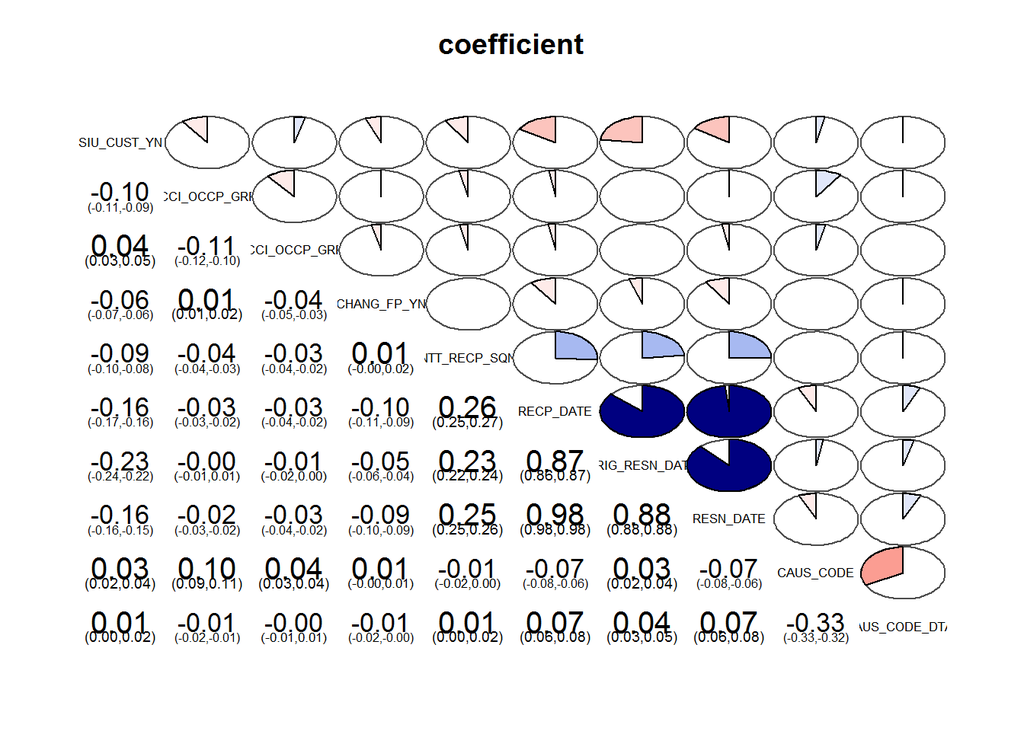

```r
## change features of factor type to numeric type for inclusion on correlogram
corrgram.data$SIU_CUST_YN <- as.numeric(corrgram.data$SIU_CUST_YN)
corrgram.data$ACCI_OCCP_GRP1 <- as.numeric(corrgram.data$ACCI_OCCP_GRP1)
corrgram.data$ACCI_OCCP_GRP2 <- as.numeric(corrgram.data$ACCI_OCCP_GRP2)
corrgram.data$CHANG_FP_YN <- as.numeric(corrgram.data$CHANG_FP_YN)
corrgram.data$CAUS_CODE <- as.numeric (corrgram.data$CAUS_CODE)
corrgram.data$CAUS_CODE_DTAL <- as.numeric (corrgram.data$CAUS_CODE_DTAL)
corrgram.data$RESL_CD1 <- as.numeric (corrgram.data$RESL_CD1)
corrgram.data$RESL_NM1 <- as.numeric (corrgram.data$RESL_NM1)
corrgram.data$ACCI_HOSP_ADDR <- as.numeric (corrgram.data$ACCI_HOSP_ADDR)
corrgram.data$PMMI_DLNG_YN <- as.numeric (corrgram.data$PMMI_DLNG_YN)
corrgram.data$HEED_HOSP_YN <- as.numeric (corrgram.data$HEED_HOSP_YN)
corrgram.data$SUB_CUST_ID <- as.numeric (corrgram.data$SUB_CUST_ID)


## generate correlogram : 피어슨 상관계수 계산
corrgram.vars <- c("SIU_CUST_YN", "ACCI_OCCP_GRP1", "ACCI_OCCP_GRP2", "CHANG_FP_YN", "CNTT_RECP_SQNO", "RECP_DATE", "ORIG_RESN_DATE", "RESN_DATE","CRNT_PROG_DVSN","ACCI_DVSN","CAUS_CODE","CAUS_CODE_DTAL")
corrgram(corrgram.data[,corrgram.vars], order=FALSE, lower.panel=panel.conf, upper.panel=panel.pie, text.panel=panel.txt, main="coefficient")
```

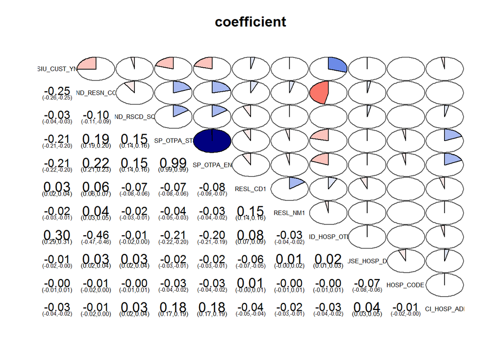

```r
corrgram.vars <- c("SIU_CUST_YN", "DSAS_NAME", "DMND_RESN_CODE", "DMND_RSCD_SQNO", "HOSP_OTPA_STDT", "HOSP_OTPA_ENDT", "RESL_CD1", "RESL_NM1","VLID_HOSP_OTDA","HOUSE_HOSP_DIST","HOSP_CODE","ACCI_HOSP_ADDR")
corrgram(corrgram.data[,corrgram.vars], order=FALSE, lower.panel=panel.conf, upper.panel=panel.pie, text.panel=panel.txt, main="coefficient")
```

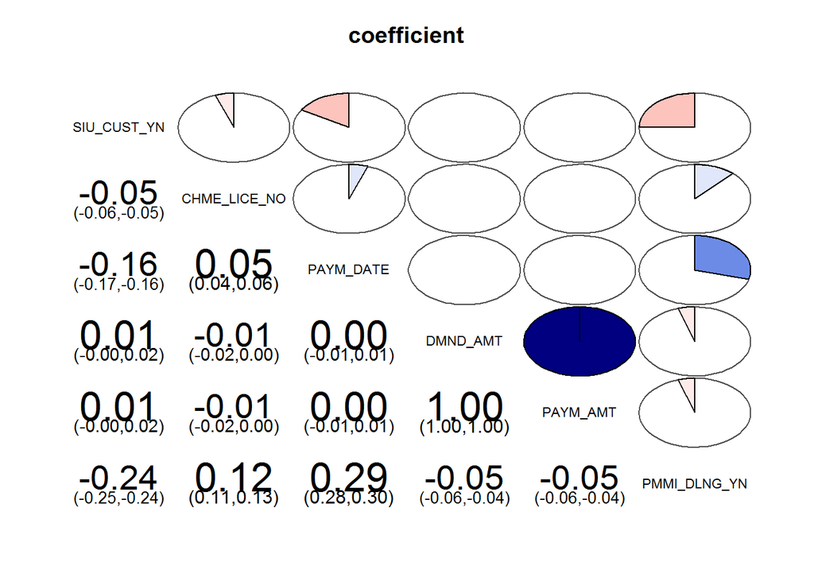

```r
corrgram.vars <- c("SIU_CUST_YN", "HOSP_SPEC_DVSN", "CHME_LICE_NO", "PAYM_DATE", "DMND_AMT", "PAYM_AMT", "PMMI_DLNG_YN")
#, "SELF_CHAM", "NON_PAY", "TAMT_SFCA","PATT_CHRG_TOTA","DSCT_AMT") #표준편차 0으로 에러 발생
corrgram(corrgram.data[,corrgram.vars], order=FALSE, lower.panel=panel.conf, upper.panel=panel.pie, text.panel=panel.txt, main="coefficient")
```

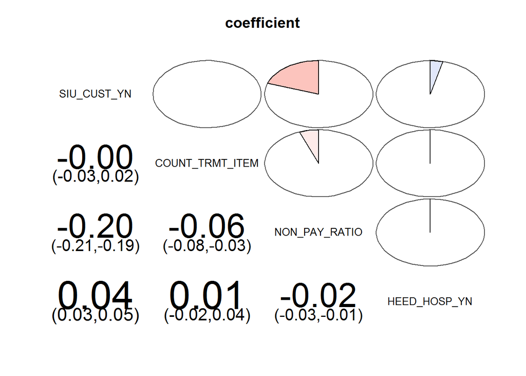

```r
corrgram.vars <- c("SIU_CUST_YN", "COUNT_TRMT_ITEM", "NON_PAY_RATIO", "HEED_HOSP_YN", "FMLY_RELN_CODE")
#, "DCAF_CMPS_XCPA", "NON_PAY_RATIO", "HEED_HOSP_YN", "SUB_CUST_ID", "FMLY_RELN_CODE") #표준편차 0으로 에러 발생
corrgram(corrgram.data[,corrgram.vars], order=FALSE, lower.panel=panel.conf, upper.panel=panel.pie, text.panel=panel.txt, main="coefficient")
```

```r
#####BGCON_CUST_DATA.df
corrgram.data <- BGCON_CUST_FMLY_DATA.df.down
names(corrgram.data)
```

```
##  [1] "CUST_ID"          "DIVIDED_SET"      "SIU_CUST_YN"
##  [4] "SEX"              "AGE"              "RESI_COST"
##  [7] "RESI_TYPE_CODE"   "FP_CAREER"        "CUST_RGST"
## [10] "CTPR"             "OCCP_GRP_1"       "OCCP_GRP_2"
## [13] "TOTALPREM"        "MINCRDT"          "MAXCRDT"
## [16] "WEDD_YN"          "MATE_OCCP_GRP_1"  "MATE_OCCP_GRP_2"
## [19] "CHLD_CNT"         "LTBN_CHLD_AGE"    "MAX_PAYM_YM"
## [22] "MAX_PRM"          "CUST_INCM"        "RCBASE_HSHD_INCM"
## [25] "JPBASE_HSHD_INCM" "SUB_CUST_ID"      "FMLY_RELN_CODE"
## [28] "Class"
```

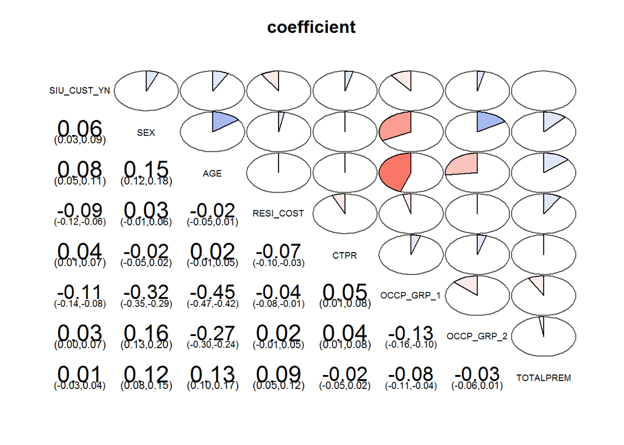

```r
## change features of factor type to numeric type for inclusion on correlogram
corrgram.data$SIU_CUST_YN <- as.numeric(corrgram.data$SIU_CUST_YN)
corrgram.data$FP_CAREER <- as.numeric(corrgram.data$FP_CAREER)
corrgram.data$CTPR <- as.numeric(corrgram.data$CTPR)
corrgram.data$OCCP_GRP_1 <- as.numeric (corrgram.data$OCCP_GRP_1)
corrgram.data$OCCP_GRP_2 <- as.numeric (corrgram.data$OCCP_GRP_2)
corrgram.data$WEDD_YN <- as.numeric (corrgram.data$WEDD_YN)
corrgram.data$MATE_OCCP_GRP_1 <- as.numeric (corrgram.data$MATE_OCCP_GRP_1)
corrgram.data$MATE_OCCP_GRP_2 <- as.numeric (corrgram.data$MATE_OCCP_GRP_2)


## generate correlogram : 피어슨 상관계수 계산
corrgram.vars <- c("SIU_CUST_YN",  "SEX",  "AGE",  "RESI_COST", "CTPR", "OCCP_GRP_1", "OCCP_GRP_2", "TOTALPREM")
corrgram(corrgram.data[,corrgram.vars], order=FALSE, lower.panel=panel.conf, upper.panel=panel.pie, text.panel=panel.txt, main="coefficient")
```

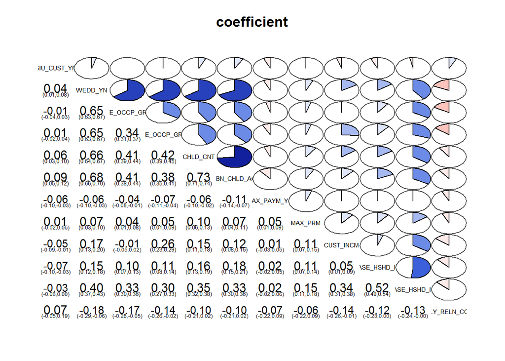

```r
corrgram.vars <- c("SIU_CUST_YN", "MINCRDT", "MAXCRDT", "WEDD_YN", "MATE_OCCP_GRP_1", "MATE_OCCP_GRP_2", "CHLD_CNT", "LTBN_CHLD_AGE", "MAX_PAYM_YM", "MAX_PRM", "CUST_INCM", "RCBASE_HSHD_INCM", "JPBASE_HSHD_INCM", "FMLY_RELN_CODE")
corrgram(corrgram.data[,corrgram.vars], order=FALSE, lower.panel=panel.conf, upper.panel=panel.pie, text.panel=panel.txt, main="coefficient")
```

```r
#####BGCON_CUST_DATA.df
corrgram.data <- BGCON_CNTT_FPINFO_DATA.df.down
names(corrgram.data)
```

```
##  [1] "CLLT_FP_PRNO"   "POLY_NO"        "CUST_ID"        "CUST_ROLE"
##  [5] "IRKD_CODE_DTAL" "IRKD_CODE_ITEM" "GOOD_CLSF_CDNM" "CNTT_YM"
##  [9] "REAL_PAYM_TERM" "SALE_CHNL_CODE" "CNTT_STAT_CODE" "EXPR_YM"
## [13] "EXTN_YM"        "LAPS_YM"        "PAYM_CYCL_CODE" "MAIN_INSR_AMT"
## [17] "SUM_ORIG_PREM"  "RECP_PUBL"      "CNTT_RECP"      "MNTH_INCM_AMT"
## [21] "DISTANCE"       "SIU_CUST_YN"    "INCB_DVSN"      "ETRS_YM"
## [25] "FIRE_YM"        "BEFO_JOB"       "EDGB"           "BRCH_CODE"
## [29] "Class"
```

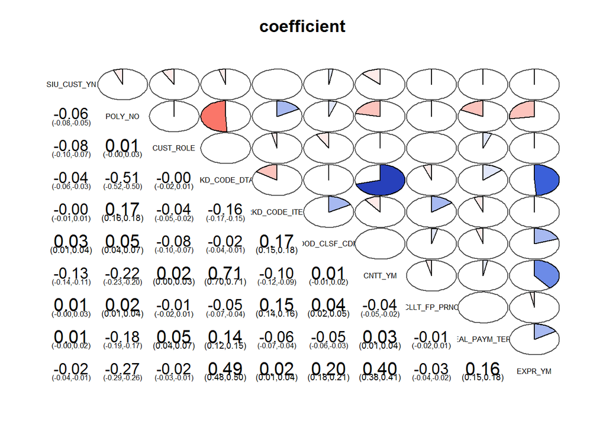

```r
## change features of factor type to numeric type for inclusion on correlogram
corrgram.data$SIU_CUST_YN <- as.numeric(corrgram.data$SIU_CUST_YN)
corrgram.data$GOOD_CLSF_CDNM <- as.numeric(corrgram.data$GOOD_CLSF_CDNM)
corrgram.data$CLLT_FP_PRNO <- as.numeric(corrgram.data$CLLT_FP_PRNO)
corrgram.data$INCB_DVSN <- as.numeric(corrgram.data$INCB_DVSN)
corrgram.data$ETRS_YM <- as.numeric(corrgram.data$ETRS_YM)
corrgram.data$FIRE_YM <- as.numeric(corrgram.data$FIRE_YM)
corrgram.data$BEFO_JOB <- as.numeric(corrgram.data$BEFO_JOB)
corrgram.data$EDGB <- as.numeric(corrgram.data$EDGB)
corrgram.data$BRCH_CODE <- as.numeric(corrgram.data$BRCH_CODE)

## generate correlogram : 피어슨 상관계수 계산
corrgram.vars <- c("SIU_CUST_YN", "POLY_NO", "CUST_ROLE", "IRKD_CODE_DTAL", "IRKD_CODE_ITEM", "GOOD_CLSF_CDNM", "CNTT_YM", "CLLT_FP_PRNO", "REAL_PAYM_TERM", "SALE_CHNL_CODE", "CNTT_STAT_CODE", "EXPR_YM")
corrgram(corrgram.data[,corrgram.vars], order=FALSE, lower.panel=panel.conf, upper.panel=panel.pie, text.panel=panel.txt, main="coefficient")
```

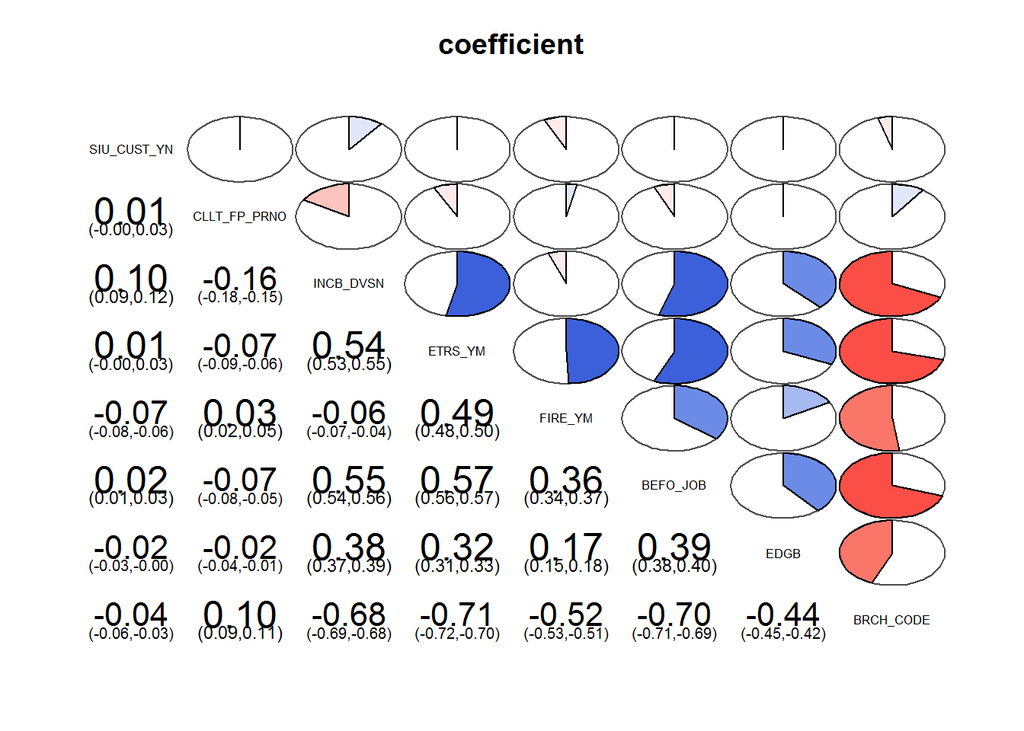

```r
## generate correlogram : 피어슨 상관계수 계산
corrgram.vars <- c("SIU_CUST_YN", "CLLT_FP_PRNO", "INCB_DVSN", "ETRS_YM", "FIRE_YM", "BEFO_JOB", "EDGB", "BRCH_CODE")
corrgram(corrgram.data[,corrgram.vars], order=FALSE, lower.panel=panel.conf, upper.panel=panel.pie, text.panel=panel.txt, main="coefficient")
```

- 데이터가 많기 때문에 p-value 계산으로 볼때 0.06 이상은 귀무가설 기각
- 상관분석에서 유의미하게 본 데이터들이 correlation이 높게 나옴

## Feature Importance 확인을 위한 모델 테스트

### CART(Classification And Regression Tree)

- ctree(Conditional Inference Tree)
- BGCON_CNTT_FPINFO_DATA.df.down
- train 16386, test 4096
- Accuracy 0.6787109 (2780/4096)
- BGCON_CUST_FMLY_DATA.df.down
- train 2962, test 740
- Accuracy 0.5851351 (433/740)

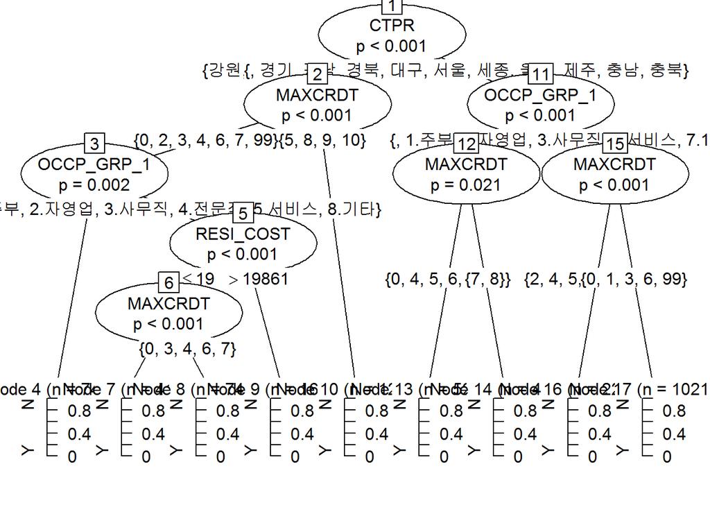

```r
#install.packages("rattle")
#install.packages("rpart.plot")
# install.packages("caret")
suppressPackageStartupMessages({
  library(rpart)
  library(rattle)
  library(rpart.plot)
  library(party)
  library(caret)
})
#입력할 데이터
df.train <- BGCON_CUST_FMLY_DATA.df.down
df.train$Class <- NULL

set.seed(23)
training.rows <- createDataPartition(df.train$SIU_CUST_YN,  p = 0.8, list = FALSE)
train.batch <- df.train[training.rows, ]
test.batch <- df.train[-training.rows, ]

#ctree를 이용해서 트리 분류
model_ctree.2 <- ctree(SIU_CUST_YN ~ ., data = train.batch)

## Plotting
plot(model_ctree.2)
```

```r
## 훈련 데이터 기반
p_ctree <- predict(model_ctree.2, newdata=test.batch, type="response")
ctree_result <- list(actual=test.batch$SIU_CUST_YN, predicted=p_ctree)

#정확도
sum(ctree_result$predicted == ctree_result$actual) / NROW(ctree_result$actual)
```

```
## [1] 0.5851351
```

```
#입력할 데이터
df.train <- BGCON_CNTT_FPINFO_DATA.df.down
df.train$Class <- NULL

set.seed(23)
training.rows <- createDataPartition(df.train$SIU_CUST_YN,  p = 0.8, list = FALSE)
train.batch <- df.train[training.rows, ]
test.batch <- df.train[-training.rows, ]

#ctree를 이용해서 트리 분류
model_ctree <- ctree(SIU_CUST_YN ~ ., data = train.batch)

## Plotting
plot(model_ctree)

## 훈련 데이터 기반
p_ctree <- predict(model_ctree, newdata=test.batch, type="response")
ctree_result <- list(actual=test.batch$SIU_CUST_YN, predicted=p_ctree)

#head를 봤더니 모두 N으로 처리한다.
head(ctree_result)

#정확도
sum(ctree_result$predicted == ctree_result$actual) / NROW(ctree_result$actual)


#입력할 데이터
df.train <- BGCON_CUST_FMLY_DATA.df.down
df.train$OCCP_GRP_1 <- NULL
df.train$OCCP_GRP_2 <- NULL
df.train$WEDD_YN <- NULL
df.train$MATE_OCCP_GRP_2 <- NULL

set.seed(23)
training.rows <- createDataPartition(df.train$SIU_CUST_YN,  p = 0.8, list = FALSE)
train.batch <- df.train[training.rows, ]
test.batch <- df.train[-training.rows, ]

ins.glm.3 <- glm(SIU_CUST_YN ~ ., data = train.batch, family=binomial("logit"))
pred <- predict(ins.glm.3, newdata=test.batch)
```

[output cut: 38 more lines]

```
                        classProbs = TRUE)

missmap(df.train, main="Missings Map", col=c("yellow", "black"), legend=FALSE)
View(df.train)

df.train <- as.factor(df.train)

#logistic 회귀로 변수 값을 종속변수 영향도를 확인해보자
set.seed(23)
glm.tune.1 <- train(SIU_CUST_YN ~ .
                    ,data = df.train
                    ,method = "svmRadial"
                    ,metric = "ROC"  ## ROC 구체적으로는 AUC 가 최대가 되도록 최적화 하겠다는 의미임
                    ,trControl = cv.ctrl)
glm.tune.1
```